# Saccoloma inaequale leaf age @ La Selva 2017

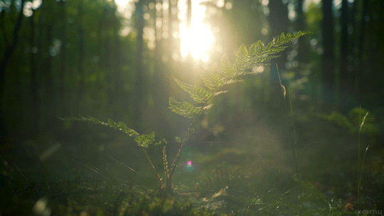

# Methods

## Site and species surveys

This study was located at La Selva Biological Research Station in Heredia, Costa Rica (84°00’12W, 10°25’52N). This site is a 600 hectare wet tropical forest, with elevation ranging from 35-137m above sea level. The site receives 4m of annual rainfall with a moderate dry season. Annual mean temperatures fluctuates between between 24-27 °C, while daily temperatures can fluctuate up to 12 °C (McDade et al. 1994).

## Physiological measurements

A survey of physiological and stoichiometric parameters was conducted on all present age classes of fronds for a subset of 10 *S. inaequale* individuals. For leaf gas exchange measurements, a LiCor 6400 portable photosynthesis system (LiCor BioSciences) was used with the standard leaf chamber (2 x 3 cm) equipped with blue-red light emitting diodes. The CO<sub>2</sub> mixer was set to 400 μmol m<sup>-2</sup> sec<sup>-1</sup> and leaf temperature was maintained at 25 °C. Gas exchange parameters were logged once CO<sub>2</sub> and water vapor fluxes were stable. Net photosynthetic rate (An) and stomatal conductance (g<sub>s</sub>) were logged at a standard photosynthetic photon flux density (PPFD) level of 500 $\mu$mol m<sup>-2</sup> s<sup>-1</sup>,which has been previously shown to produce maximum photosynthetic rates for tropical understory terrestrial plants (Watkins et al 2010). All in situ gas exchange measurements were conducted during mid-morning hours.

## Chlorophyll content

# Preliminary data summary

Below are the boxplots (excluding outliers) for physiological measurements, including; photosynthesis (A<sub>n</sub>), stomatal conductance (g<sub>s</sub>), instantaneous water use efficiency (ITE), transpiration (E<sub>l</sub>) and chlorophyll content. Gas exchange was performed on a subset of individuals (n=10).

There is an issue with the gas exchange data from some fronds for individual #26 (2<sup>nd</sup> and 3<sup>rd</sup> year fronds). I have deleted it from physiology figures at the moment. I pasted the raw deleted data at the bottom so you can have a look.

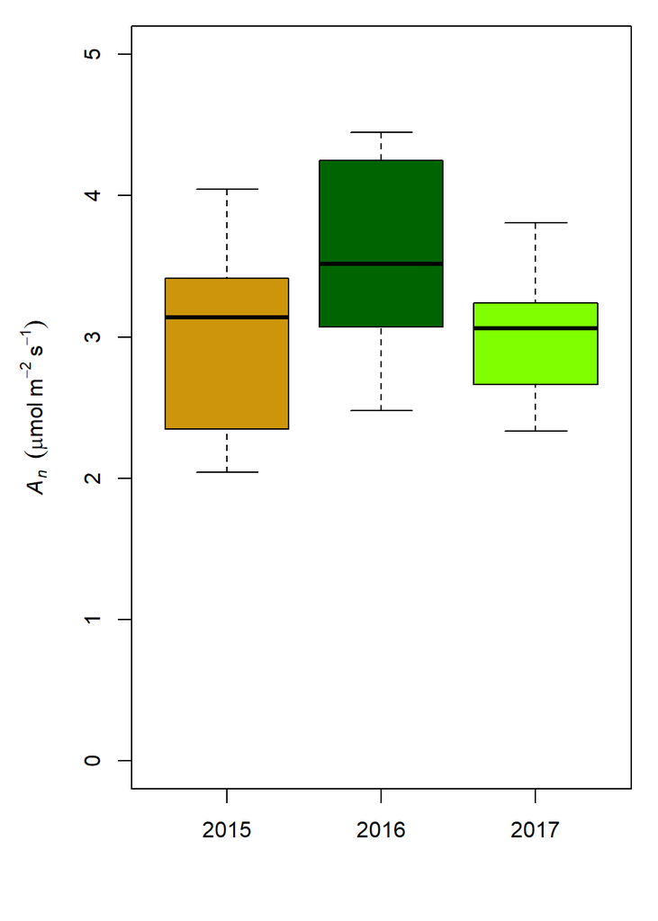

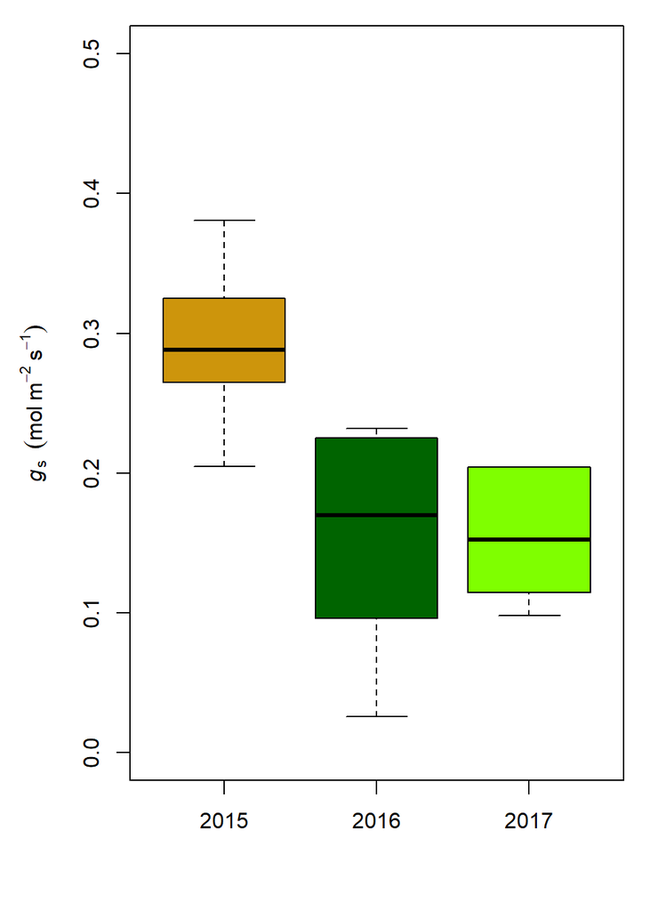

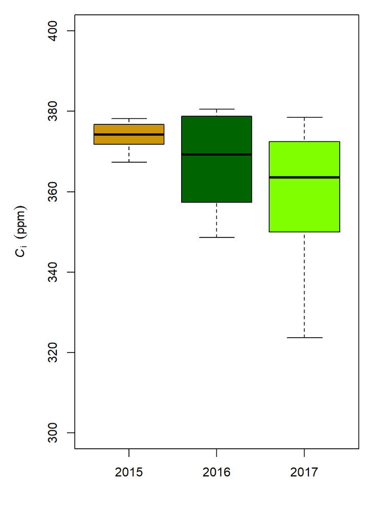

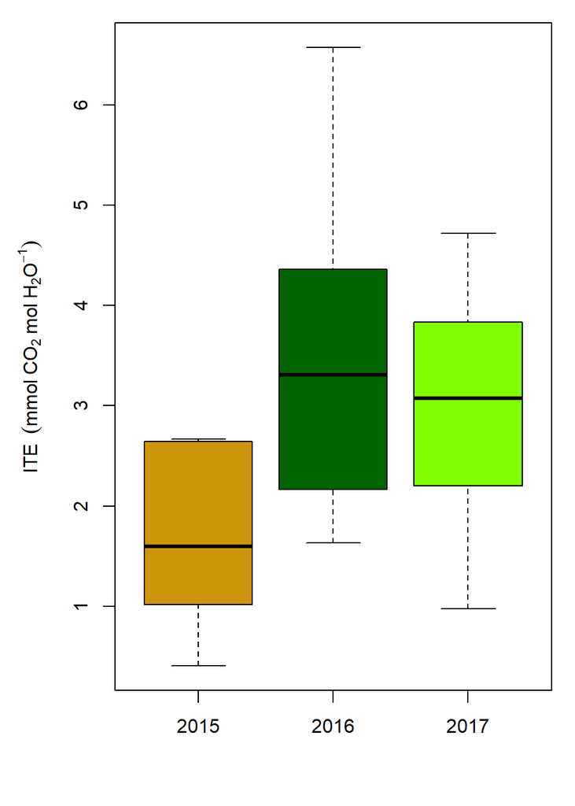

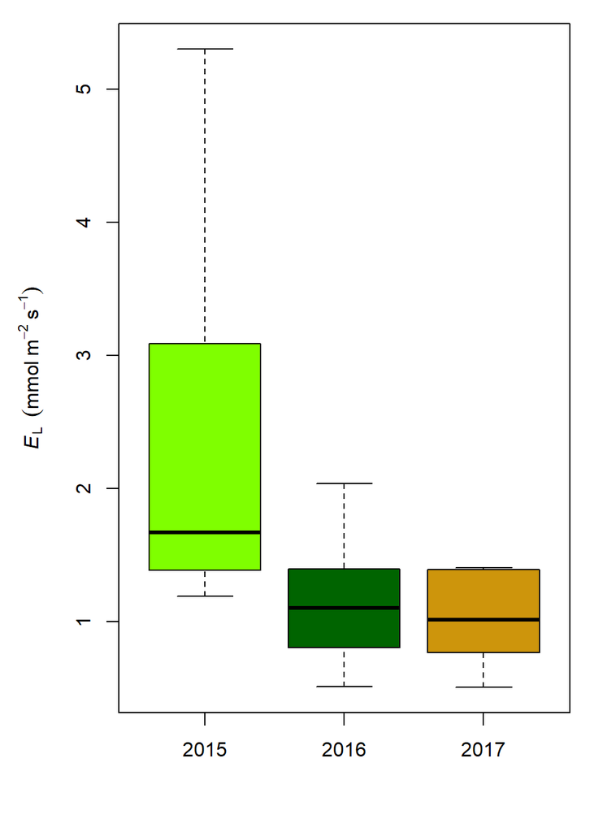

Instantaneous water use efficiency looks like it declines in year 3,likely driven by transpiration instead of A<sub>n</sub>

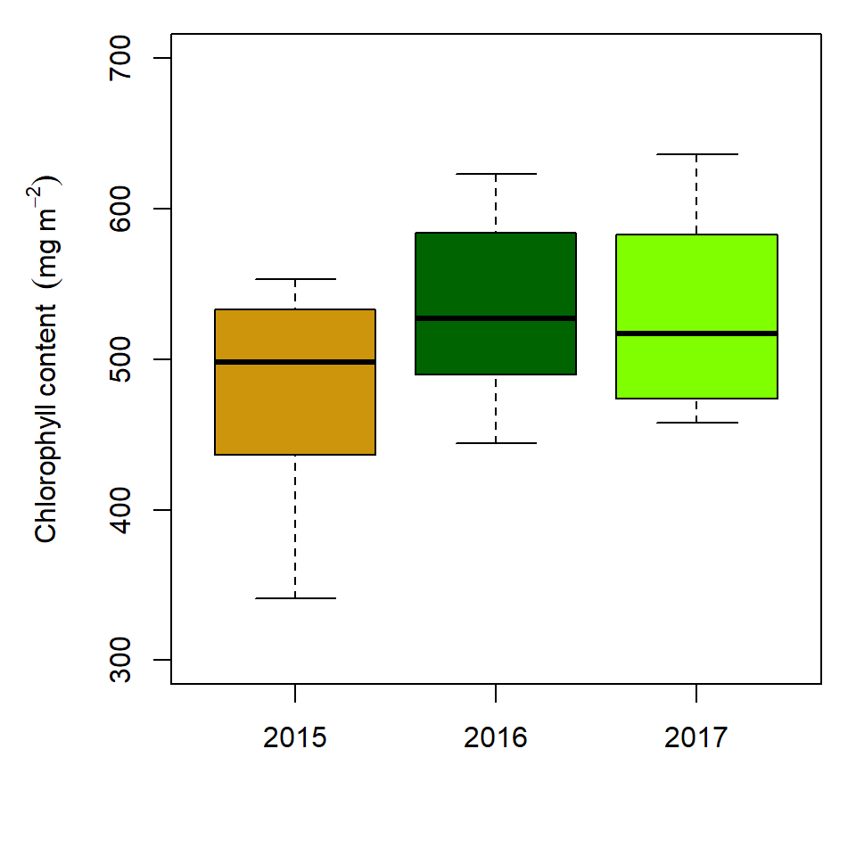

### Traits by leaf age

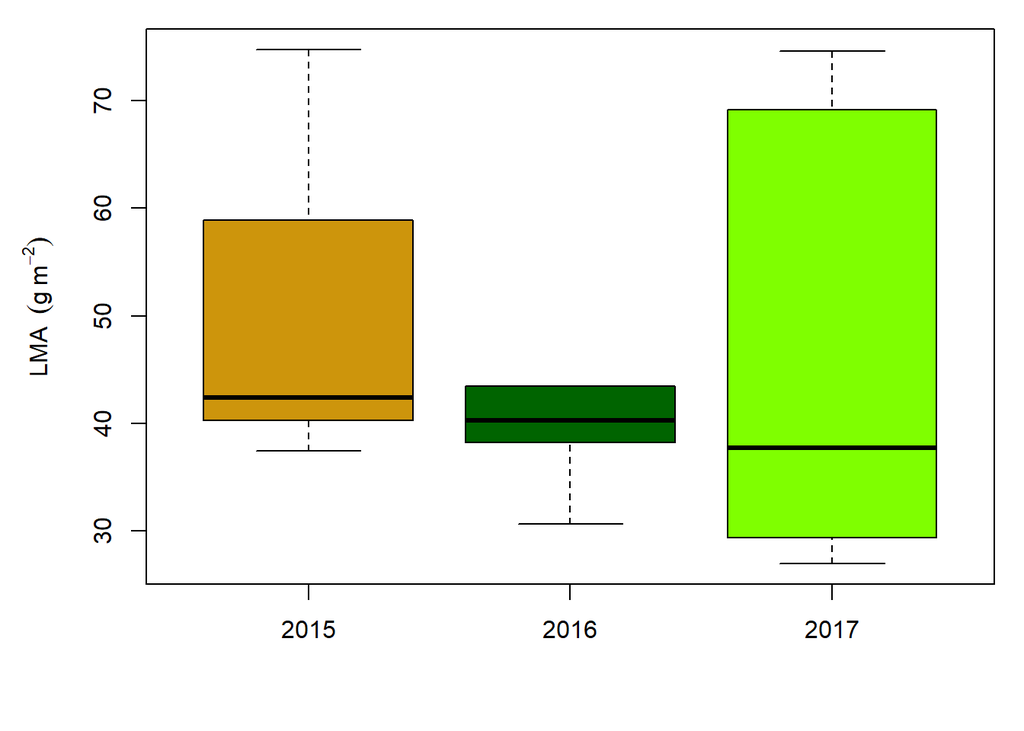

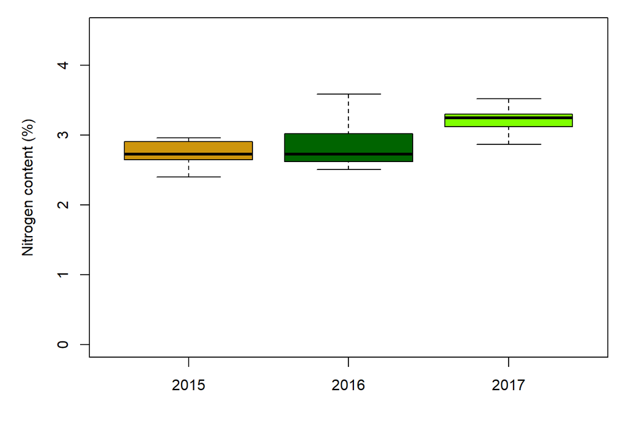

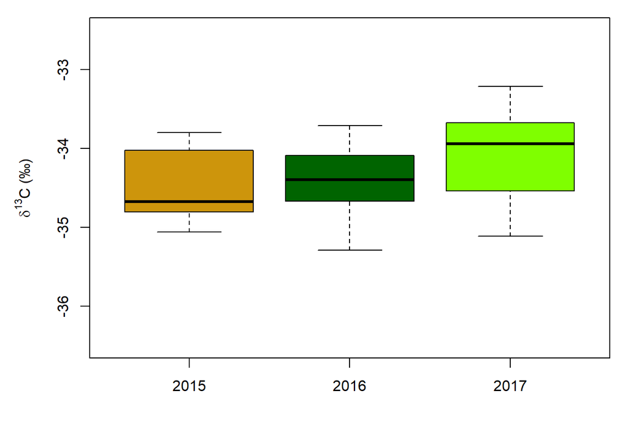

## Bivariate relationships

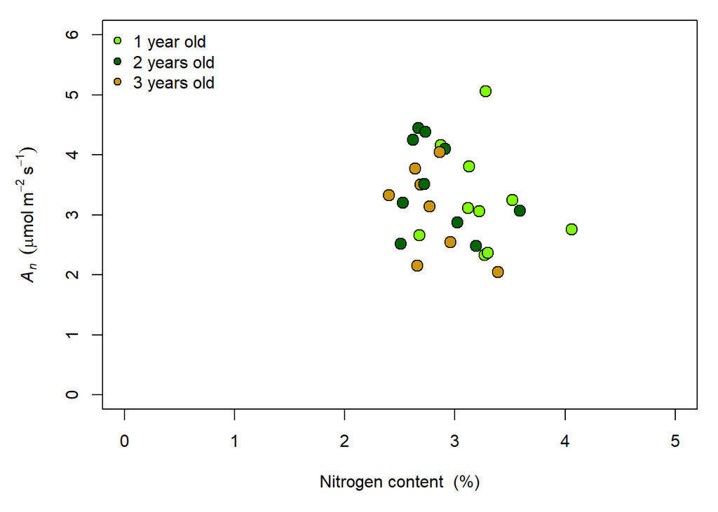

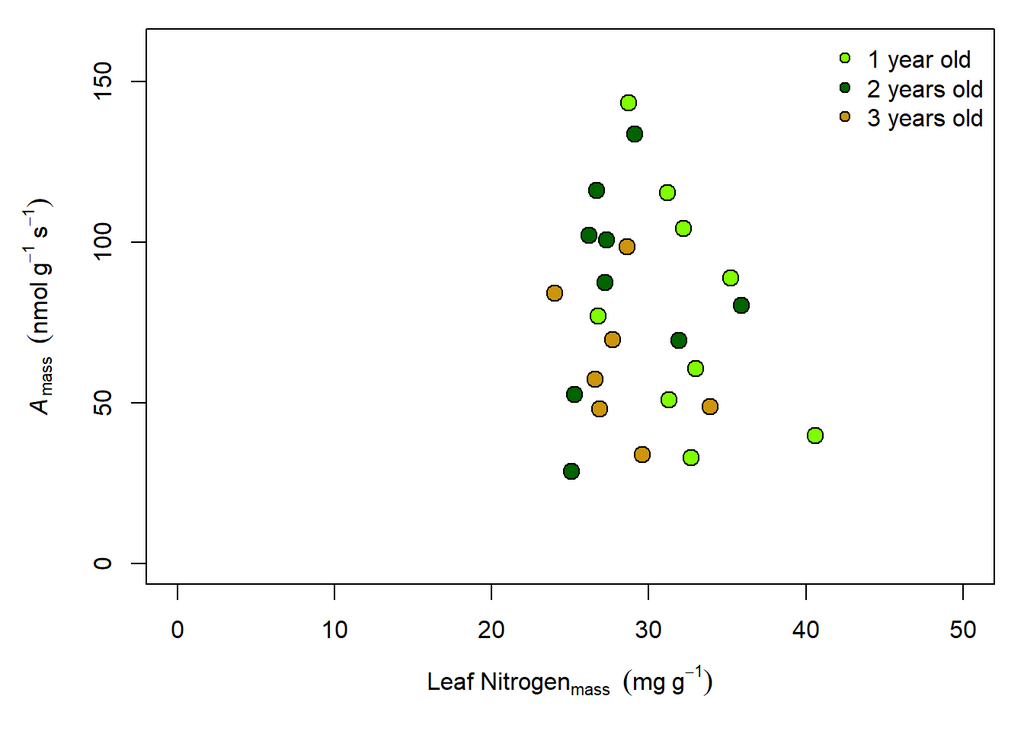

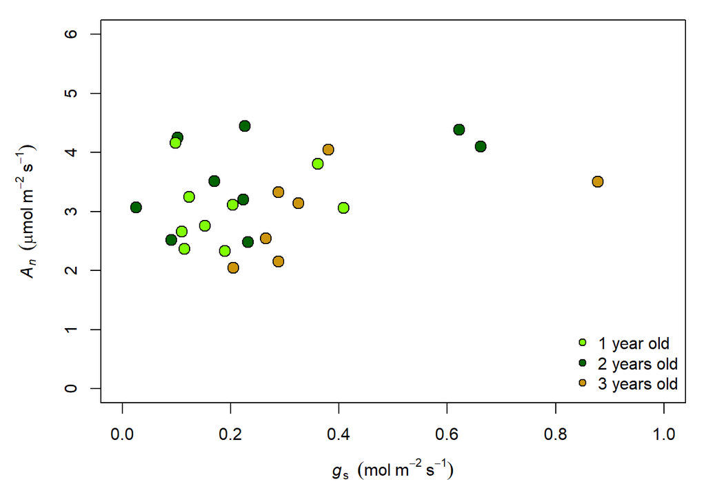

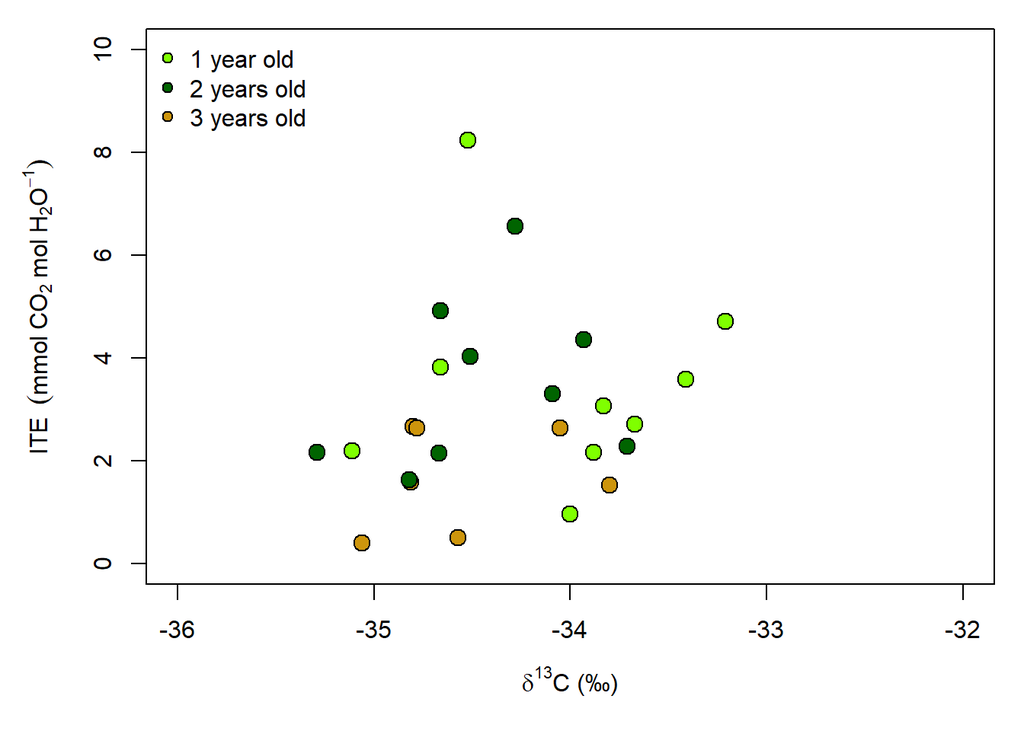

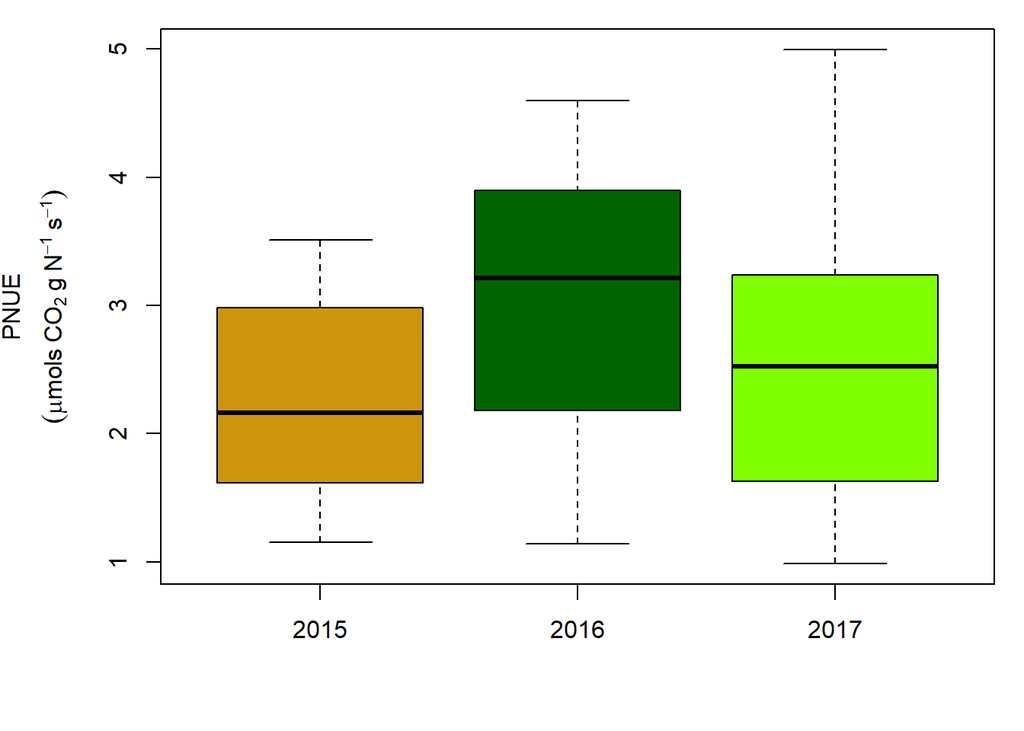

### Transpiration data seems bad for certain ages for #26

```r
photo[photo$Indiv == 26, c("Indiv", "Photo", "Cond", "Trmmol", "Ci")]
```

```
##     Indiv    Photo        Cond      Trmmol            Ci
## 126    26 2.824424  0.04675524  0.23189451    295.715372
## 127    26 2.904937  0.04856116  0.24026454    296.610524
## 128    26 2.892093  0.05008391  0.24733693    299.905604
## 129    26 2.842304  0.05027426  0.24760333    301.860485
## 130    26 2.914478  0.05171821  0.25459295    302.094215
## 131    26 4.609996  0.23620553  1.17445255    359.434307
## 132    26 5.005046  0.23242589  1.15506460    356.139980
## 133    26 6.115575  0.23133812  1.14665426    348.475770
## 134    26 5.158546  0.22737963  1.12857218    355.295895
## 135    26 4.904599  0.22759632  1.12539941    357.250962
## 136    26 4.955464  0.22556127  1.11609797    356.567020
## 137    26 4.832140  0.22344820  1.10621043    357.190813
## 138    26 4.901738  0.22084907  1.09297862    356.095426
## 139    26 3.501050 -0.11815613 -0.89533178    436.375503
## 140    26 4.299755 -0.08520550 -0.59366998    470.254426
## 141    26 3.802566 -0.05946067 -0.39221844    492.464190
## 142    26 3.752104 -0.03605563 -0.22764603    556.507654
## 143    26 3.652737 -0.01536409 -0.09336252    769.503156
## 144    26 3.646284  0.00009900  0.00058572 -58274.990560
## 145    26 3.728219  0.01488440  0.08604899     -8.000332
```